# DESeq2 Project

Devika Godbole

2022-11-16

## 1 Intro and Data Loading

One of the deadliest malignant illnesses, pancreatic ductal adenocarcinoma (PDAC), which accounts for 90% of all pancreatic cancers, has an overall five-year survival rate of 8% for all stages combined and is the fourth highest cause of cancer-related death worldwide. Two frequently used tumor cell lines for in vitro research of PDAC carcinogenesis are MIAPaCa-2 and PANC-1. There is an urgent need to better understand the molecular pathophysiology of PDAC. Although PANC-1 and MIA PaCa-2 are not well differentiated, their physical characteristics differ significantly. For instance, there are significant molecular disparity between PANC-1, which is generated from a patient with metastasis, and MIA PaCa-2, whose patient’s metastatic status is unknown. Hence, it is of great value to explore the difference between these two cell lines to potentiall identify genes for tareted therapetics for PANC-1.

This project is aimed to conduct a differential expression analysis on the transcriptome of three MIAPaCa-2 and three PANC-1 cell samples using DESeq2. The raw count data of RNA expression of these samples are obtained from the GEO database on NCBI (https://www.ncbi.nlm.nih.gov/geo/query/acc.cgi?acc=GSE169758).

```r
count_matrix = read.table("GSE169758_count_matrix.txt", header=TRUE)
head(count_matrix)
```

```
##                 Mic1 Mic2 Mic3 Mic4 Mic5 Mic6 Pan1 Pan2 Pan3 Pan4 Pan5 Pan6
## ENSG00000000003    2    0    0    1    0    0  412  140  264  467  564  296
## ENSG00000000005    0    0    0    0    0    0    0    0    0    1    0    0
## ENSG00000000419 3410 1180 1126 2153 2754 1302 1953  782 1397 2236 2580 1937
## ENSG00000000457  554  169  173  377  324  187  235  182  309  489  408  453
## ENSG00000000460 1222  389  232  445  709  428  418  264  498  648  536  726
## ENSG00000000938    3    0    0    2    1    0    1    0    1    1    0    1
```

We will proceed only using Mic1~Mic3 & Pan1~Pan3 in this project because they are the original cell lines while Mic4~Mic6 & Pan4~Pan6 have a RMB3 knockdown.

```r
count_matrix = count_matrix[,-which(colnames(count_matrix) %in% c("Mic4","Mic5","Mic6","Pan4","Pan5","Pan6"))]
head(count_matrix)
```

```
##                 Mic1 Mic2 Mic3 Pan1 Pan2 Pan3
## ENSG00000000003    2    0    0  412  140  264
## ENSG00000000005    0    0    0    0    0    0
## ENSG00000000419 3410 1180 1126 1953  782 1397
## ENSG00000000457  554  169  173  235  182  309
## ENSG00000000460 1222  389  232  418  264  498
## ENSG00000000938    3    0    0    1    0    1
```

```r
coldata = data.frame(condition = factor(rep(c('Mic', 'Pan'), each = 3), levels = c('Mic', 'Pan')))
```

## 2 Running DESeq2

DESeq2 is very simple programming wise at a base level. We first instansiate the data set that DESeq2 reads and then run the code.

```r
deseq_dataset = DESeqDataSetFromMatrix(countData = count_matrix, colData = coldata, design= ~condition)
deseq_dataset
```

```
## class: DESeqDataSet
## dim: 63677 6
## metadata(1): version
## assays(1): counts
## rownames(63677): ENSG00000000003 ENSG00000000005 ... ENSG00000273492
##   ENSG00000273493
## rowData names(0):
## colnames(6): Mic1 Mic2 ... Pan2 Pan3
## colData names(1): condition
```

```r
deseq_dataset_mean = DESeq(deseq_dataset,  # the dataset used
                           fitType = 'mean',  # use the mean of gene-wise dispersion estimates
                           minReplicatesForReplace = 7,  # the minimum number of replicates required in order to use replaceOutliers on a sample
                           parallel = TRUE)  # Enable parallization using milti-threading
```

We set minReplicatesForReplace, to 7 because that was the default in the paper. However, here we only have 3 samples genes worth of information by condition so outlying genes will just be dropped from the analysis.

```r
head(deseq_dataset_mean)
```

```
## class: DESeqDataSet
## dim: 6 6
## metadata(1): version
## assays(4): counts mu H cooks
## rownames(6): ENSG00000000003 ENSG00000000005 ... ENSG00000000460
##   ENSG00000000938
## rowData names(22): baseMean baseVar ... deviance maxCooks
## colnames(6): Mic1 Mic2 ... Pan2 Pan3
## colData names(2): condition sizeFactor
```

```r
result = results(deseq_dataset_mean,
                 contrast = c('condition', 'Pan', 'Mic'), cooksCutoff=TRUE, independentFiltering=TRUE)
result
```

```
## log2 fold change (MLE): condition Pan vs Mic
## Wald test p-value: condition Pan vs Mic
## DataFrame with 63677 rows and 6 columns
##                  baseMean log2FoldChange     lfcSE      stat      pvalue
##                 <numeric>      <numeric> <numeric> <numeric>   <numeric>
## ENSG00000000003   135.522      8.9871794  1.142404  7.866904 3.63526e-15
## ENSG00000000005     0.000             NA        NA        NA          NA
## ENSG00000000419  1464.927     -0.1563720  0.285827 -0.547086 5.84320e-01
## ENSG00000000457   244.817      0.0892883  0.280505  0.318312 7.50248e-01
## ENSG00000000460   435.423     -0.2040060  0.401478 -0.508137 6.11357e-01
## ...                   ...            ...       ...       ...         ...
## ENSG00000273489  5.439903      -3.987512  1.349017  -2.95587  0.00311793
## ENSG00000273490  0.000000             NA        NA        NA          NA
## ENSG00000273491  0.000000             NA        NA        NA          NA
## ENSG00000273492 17.899958      -0.912159  0.494417  -1.84492  0.06504940
## ENSG00000273493  0.212296      -0.906743  2.757312  -0.32885  0.74226878
##                        padj
##                   <numeric>
## ENSG00000000003 9.79140e-14
## ENSG00000000005          NA
## ENSG00000000419 7.18170e-01
## ENSG00000000457 8.42602e-01
## ENSG00000000460 7.39196e-01
## ...                     ...
## ENSG00000273489   0.0114889
## ENSG00000273490          NA
## ENSG00000273491          NA
## ENSG00000273492   0.1431205
## ENSG00000273493          NA
```

In these results we see baseMean, which is the mean of normlized counts across all samples, we see the log2foldchange which is the log2fold change (MLE) Pan vs Mic, the lfcSE, which is the standard error, stat which is the Wald test statistic for Pan vs Mic, the p value for significant difference between Pan vs Mic, and the adjusted pvalue which is the pvalue adjusted for multiple comparisons.

```r
summary(result)
```

```
##
## out of 31896 with nonzero total read count
## adjusted p-value < 0.1
## LFC > 0 (up)       : 5482, 17%
## LFC < 0 (down)     : 4609, 14%
## outliers [1]       : 11, 0.034%
## low counts [2]     : 7617, 24%
## (mean count < 1)
## [1] see 'cooksCutoff' argument of ?results
## [2] see 'independentFiltering' argument of ?results
```

We see above that, 17% of genes tested in our project are marked up-regulated and 14% of them are down-regulated. Only 0.034% of genes are outliers. We have a lot, 24%, of low-expressed genes in the in the result.

```r
table(result$padj<0.05)
```

```
##
## FALSE  TRUE
## 15660  8608
```

```r
result_up = result[which(result$log2FoldChange >= 1 & result$pvalue < 0.05),]
result_down = result[which(result$log2FoldChange <= -1 & result$pvalue < 0.05),]
result_total = rbind(result_up,result_down)
write.csv(result_total, file = "DEG_Mic_vs_PANC.csv")
```

Here we see there are 8608 genes that have a padj value less than 0.05. We will define upregulated genes as ones who have a log2FoldChange >= 1 & pvalue < 0.05. We will define down regulated genes as ones who have a log2FoldChange <= -1 & pvalue < 0.05. We save these results to a csv.

Now, we can do this again but utilizing DESeq2’s shrinkage.

```r
dds <- DESeq(deseq_dataset)
res <- results(dds)
resultsNames(dds)
```

```
## [1] "Intercept"            "condition_Pan_vs_Mic"
```

```r
resLFC <- lfcShrink(dds, coef="condition_Pan_vs_Mic", type = "normal")
```

```
## using 'normal' for LFC shrinkage, the Normal prior from Love et al (2014).
##
## Note that type='apeglm' and type='ashr' have shown to have less bias than type='normal'.
## See ?lfcShrink for more details on shrinkage type, and the DESeq2 vignette.
## Reference: https://doi.org/10.1093/bioinformatics/bty895
```

```r
resLFC
```

```
## log2 fold change (MAP): condition Pan vs Mic
## Wald test p-value: condition Pan vs Mic
## DataFrame with 63677 rows and 6 columns
##                  baseMean log2FoldChange     lfcSE      stat      pvalue
##                 <numeric>      <numeric> <numeric> <numeric>   <numeric>
## ENSG00000000003   135.522      7.6689279  0.677946  8.559063 1.13788e-17
## ENSG00000000005     0.000             NA        NA        NA          NA
## ENSG00000000419  1464.927     -0.1545941  0.218204 -0.708481 4.78647e-01
## ENSG00000000457   244.817      0.0867607  0.244751  0.354481 7.22979e-01
## ENSG00000000460   435.423     -0.2023189  0.278655 -0.726036 4.67817e-01
## ...                   ...            ...       ...       ...         ...
## ENSG00000273489  5.439903      -2.835048  0.963679 -2.718607  0.00655574
## ENSG00000273490  0.000000             NA        NA        NA          NA
## ENSG00000273491  0.000000             NA        NA        NA          NA
## ENSG00000273492 17.899958      -0.860180  0.550219 -1.561312  0.11845025
## ENSG00000273493  0.212296      -0.185252  0.913105 -0.236155  0.81331243
##                        padj
##                   <numeric>
## ENSG00000000003 2.21764e-16
## ENSG00000000005          NA
## ENSG00000000419 6.25252e-01
## ENSG00000000457 8.23201e-01
## ENSG00000000460 6.15390e-01
## ...                     ...
## ENSG00000273489    0.018467
## ENSG00000273490          NA
## ENSG00000273491          NA
## ENSG00000273492    0.216194
## ENSG00000273493          NA
```

```r
summary(resLFC)
```

```
##
## out of 31896 with nonzero total read count
## adjusted p-value < 0.1
## LFC > 0 (up)       : 5531, 17%
## LFC < 0 (down)     : 4895, 15%
## outliers [1]       : 11, 0.034%
## low counts [2]     : 9375, 29%
## (mean count < 1)
## [1] see 'cooksCutoff' argument of ?results
## [2] see 'independentFiltering' argument of ?results
```

```r
table(resLFC$padj<0.05)
```

```
##
## FALSE  TRUE
## 13233  9277
```

```r
result_up = resLFC[which(resLFC$log2FoldChange >= 1 & resLFC$pvalue < 0.05),]
result_down = resLFC[which(resLFC$log2FoldChange <= -1 & resLFC$pvalue < 0.05),]
result_total = rbind(result_up,result_down)
write.csv(result_total, file = "DEG_Mic_vs_PANC.csv")
```

Now, we see that 17% of genes tested in our project are marked up-regulated and 15% of them are down-regulated. Only 0.034% of genes are outliers. We have a lot, 29%, of low-expressed gene. Overall, this result was similar to the MLE version in this case.

## Results and Visualizations

Here we only have the Ensembl gene id in the raw dataset, to make our result more intuitive, it is necessary to annotate them with gene names. In this project, BiomaRt was used for annotation.

```r
mart = useDataset("hsapiens_gene_ensembl", useMart("ensembl")) # Create the Mart object
diff_gene_id = row.names(result_total) # Extract the ensembl gene id
hg_symbols = getBM(attributes=c('ensembl_gene_id','external_gene_name',"description"),
                   filters = 'ensembl_gene_id',
                   value = diff_gene_id,
                   mart = mart) # Retrieves information from the BioMart database
# Reformat the result Dataframe
     # Add a now column "ensembl_gene_id"
ensembl_gene_id = rownames(result_total)
result_total = cbind(ensembl_gene_id, result_total)
colnames(result_total)[1]<-c("ensembl_gene_id")
    # Combine the gene name and the original result
diff_name = merge(result_total,hg_symbols,by="ensembl_gene_id")
head(diff_name)
```

```
## DataFrame with 6 rows and 9 columns
##   ensembl_gene_id  baseMean log2FoldChange     lfcSE      stat      pvalue
##       <character> <numeric>      <numeric> <numeric> <numeric>   <numeric>
## 1 ENSG00000000003  135.5221        7.66893  0.677946   8.55906 1.13788e-17
## 2 ENSG00000001084 1194.5881        1.97596  0.386597   5.11071 3.20952e-07
## 3 ENSG00000001561   93.9563        7.96840  0.803716   8.29936 1.04670e-16
## 4 ENSG00000001617  632.5115        3.06643  0.645089   4.75356 1.99871e-06
## 5 ENSG00000002016  436.2697       -1.34429  0.241779  -5.55960 2.70401e-08
## 6 ENSG00000002079  644.6285       -4.78405  0.749118  -6.37900 1.78248e-10
##          padj external_gene_name            description
##     <numeric>        <character>            <character>
## 1 2.21764e-16             TSPAN6 tetraspanin 6 [Sourc..
## 2 2.06654e-06               GCLC glutamate-cysteine l..
## 3 1.88791e-15              ENPP4 ectonucleotide pyrop..
## 4 1.13130e-05             SEMA3F semaphorin 3F [Sourc..
## 5 2.02419e-07              RAD52 RAD52 homolog, DNA r..
## 6 1.72575e-09              MYH16 myosin heavy chain 1..
```

```r
write.csv(diff_name, file = "DEG_Mic_vs_PANC_annotated.csv")
```

We save these resuts with the annotated gene names and descriptions to csv.

```r
diff_name_sorted = diff_name[order(diff_name$log2FoldChange,decreasing = TRUE),]
head(diff_name_sorted)
```

```
## DataFrame with 6 rows and 9 columns
##   ensembl_gene_id  baseMean log2FoldChange     lfcSE      stat       pvalue
##       <character> <numeric>      <numeric> <numeric> <numeric>    <numeric>
## 1 ENSG00000164171   2264.24        11.2795  0.610037   12.5816  2.66433e-36
## 2 ENSG00000087245   2446.99        11.2669  0.563115   14.4350  3.11565e-47
## 3 ENSG00000111716   5662.77        10.9620  0.379926   26.5766 1.26533e-155
## 4 ENSG00000106541   1913.41        10.9439  0.565603   14.0451  8.25789e-45
## 5 ENSG00000112297   1407.58        10.7980  0.601676   12.1798  3.98264e-34
## 6 ENSG00000123364   1407.79        10.7914  0.609292   12.0935  1.14346e-33
##           padj external_gene_name            description
##      <numeric>        <character>            <character>
## 1  1.59505e-34              ITGA2 integrin subunit alp..
## 2  2.86258e-45               MMP2 matrix metallopeptid..
## 3 2.84827e-152               LDHB lactate dehydrogenas..
## 4  7.04110e-43               AGR2 anterior gradient 2,..
## 5  2.14472e-32             CRYBG1 crystallin beta-gamm..
## 6  6.05632e-32             HOXC13 homeobox C13 [Source..
```

We can now start to visualize our data, we start with making a heat map.

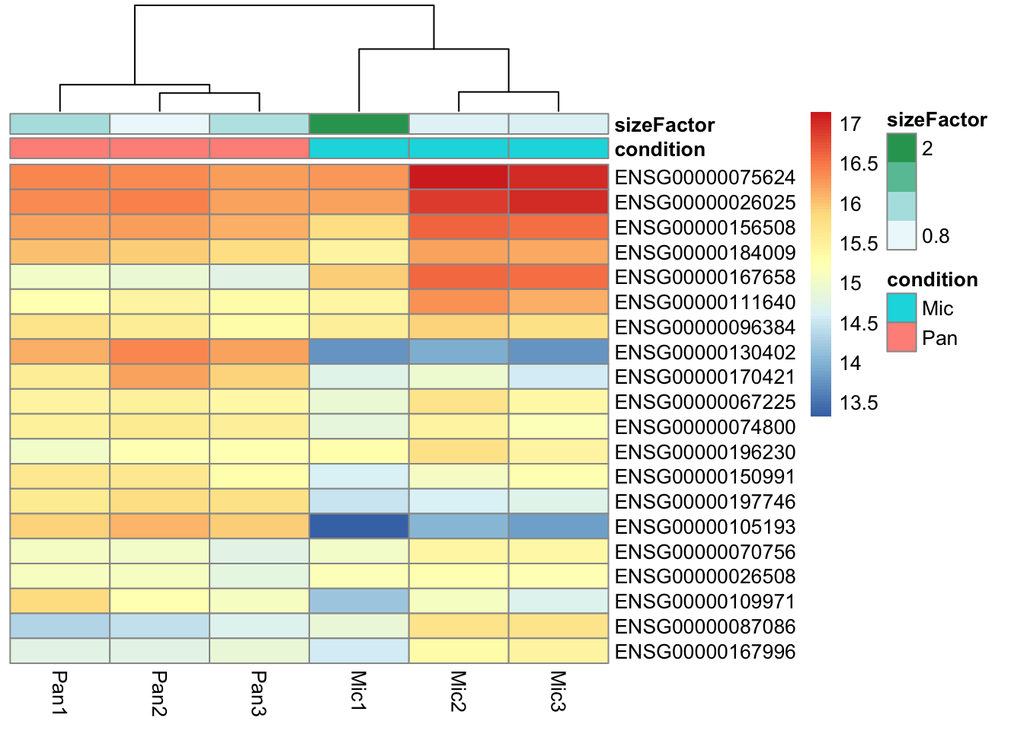

```r
select = order(rowMeans(counts(deseq_dataset_mean, normalized = TRUE)), decreasing = TRUE)[1:20]
normal_deseq_dataset_mean = normTransform(deseq_dataset_mean)
df = as.data.frame(colData(deseq_dataset_mean)[,c("condition", "sizeFactor")])
pheatmap(assay(normal_deseq_dataset_mean)[select,], cluster_rows=FALSE, show_rownames=TRUE, cluster_cols=TRUE, annotation_col=df)
```

Next, we can pick a gene with high log2FoldChange and plotted its expression level among all samples. According to recent publications, FOXA2 is a tumor suppressor in pancreatic cancer and it controls the cis-regulatory networks of pancreatic cancer cells in a differentiation grade-specific manner. Hence, it contributes to the heterogeneity of PDAC cells and should be carefully considered when testing drugs on different cell lines.

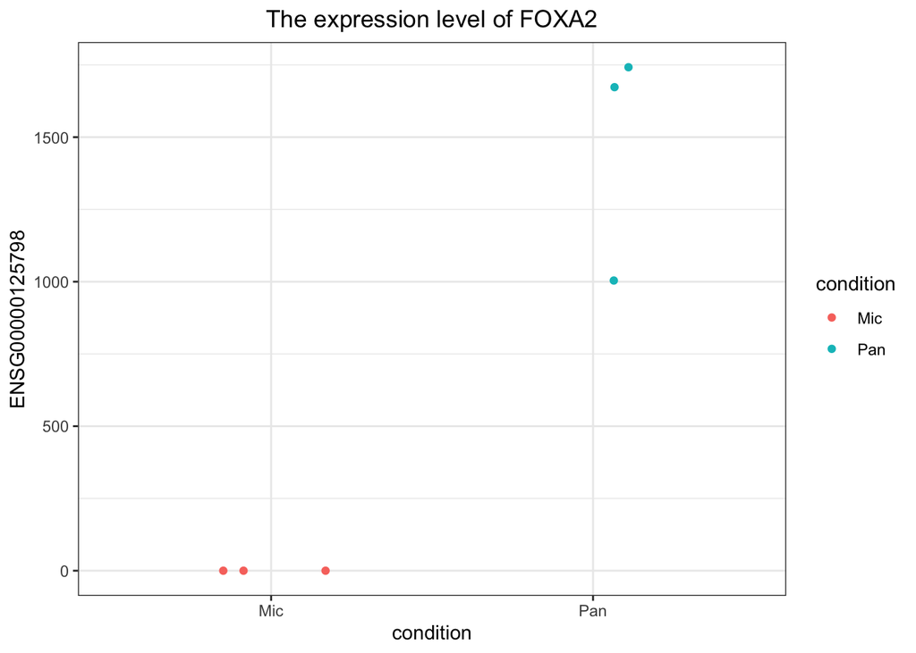

```r
d = data.frame(t(subset(count_matrix,rownames(count_matrix)=="ENSG00000125798")))
condition = factor(rep(c('Mic', 'Pan'), each = 3))
ggplot(d, aes(x = condition, y = ENSG00000125798, color = condition))+
  geom_point(position=position_jitter(w=0.2,h=0))+
  theme_bw()+
  ggtitle("The expression level of FOXA2")+
  theme(plot.title=element_text(hjust=0.5))
```

In the plot above, we see that FOXA2 does not express in the MIA PaCa-2 cell line but is highly expressed in the PANC-1 cell line.

```r
vsd <- vst(dds, blind=FALSE)
rld <- rlog(dds, blind=FALSE)
head(assay(vsd), 3)
```

```
##                      Mic1     Mic2     Mic3      Pan1      Pan2      Pan3
## ENSG00000000003  5.651658  5.43544  5.43544  8.801108  8.136064  8.356911
## ENSG00000000005  5.435440  5.43544  5.43544  5.435440  5.435440  5.435440
## ENSG00000000419 10.769706 10.66530 10.56946 10.821474 10.240930 10.443294
```

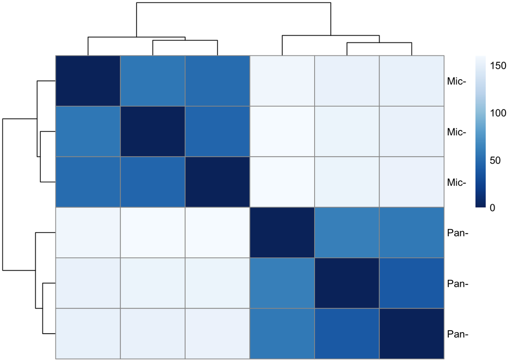

```r
sampleDists <- dist(t(assay(vsd)))
library("RColorBrewer")
sampleDistMatrix <- as.matrix(sampleDists)
rownames(sampleDistMatrix) <- paste(vsd$condition, vsd$type, sep="-")
colnames(sampleDistMatrix) <- NULL
colors <- colorRampPalette( rev(brewer.pal(9, "Blues")) )(255)
pheatmap(sampleDistMatrix,
         clustering_distance_rows=sampleDists,
         clustering_distance_cols=sampleDists,
         col=colors)
```

Here we made a heatmap of the distance matrix that gives us an overview over similarities and dissimilarities between samples.

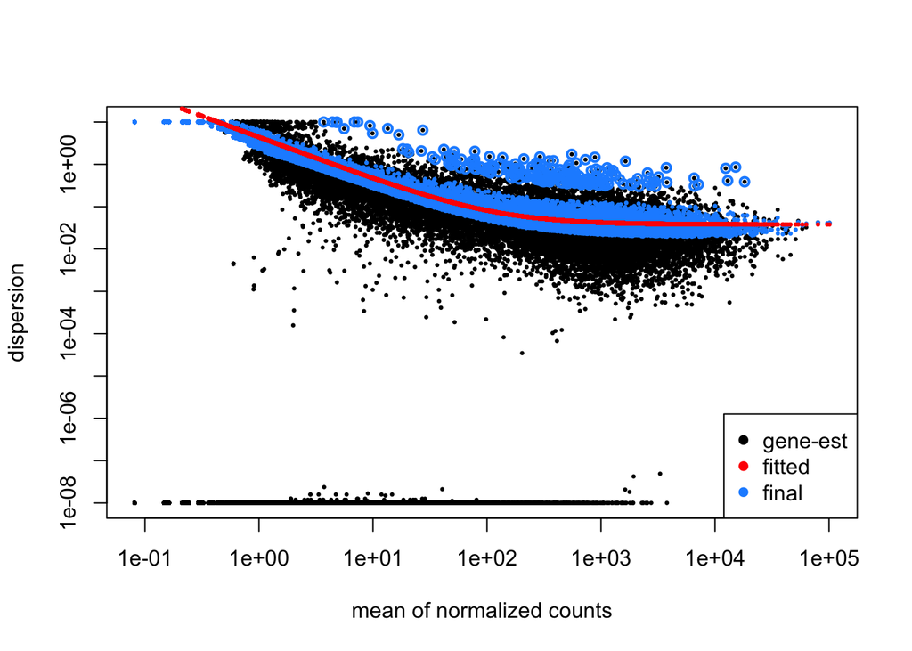

```r
plotDispEsts(dds)
```

Plotting the dispersion estimates is a useful diagnostic. The dispersion plot below is typical, with the final estimates shrunk from the gene-wise estimates towards the fitted estimates. Some gene-wise estimates are flagged as outliers and not shrunk towards the fitted value, (this outlier detection is described in the manual page for estimateDispersionsMAP). The amount of shrinkage can be more or less than seen here, depending on the sample size, the number of coefficients, the row mean and the variability of the gene-wise estimates.

```r
mart = useDataset("hsapiens_gene_ensembl", useMart("ensembl")) # Create the Mart object
diff_gene_id_all = row.names(result) # Extract the ensembl gene id
hg_symbols_all = getBM(attributes=c('ensembl_gene_id','external_gene_name',"description"),
                   filters = 'ensembl_gene_id',
                   value = diff_gene_id_all,
                   mart = mart) # Retrieves information from the BioMart database
# Reformat the result Dataframe
     # Add a now column "ensembl_gene_id"
ensembl_gene_id_all = rownames(result)
result = cbind(ensembl_gene_id_all, result)
colnames(result)[1]<-c("ensembl_gene_id")
    # Combine the gene name and the original result
diff_name_all = merge(result,hg_symbols_all,by="ensembl_gene_id")
```

```r
EnhancedVolcano(diff_name_all,
                lab = diff_name_all[,8],
                labSize = 2,
                x = "log2FoldChange",
                y = "pvalue",
                xlab = bquote(~Log[2]~ "fold change"),
                ylab = bquote(~-Log[10]~italic(P)),
                pCutoff = 0.05,
                FCcutoff = 2,
                xlim = c(-15,15),
                ylim = c(0,200),
                colAlpha = 0.6,
                legendLabels =c("None","Log2 FC"," p-value",
                                " p-value & Log2 FC"),
                legendPosition = "top",
                legendLabSize = 10,
                legendIconSize = 3.0,
                pointSize = 1.5,
                title ="DESeq2 results for PANC-1 and MIAPaCa-2 ",
                subtitle = 'Differential Expression Genes',
)
```

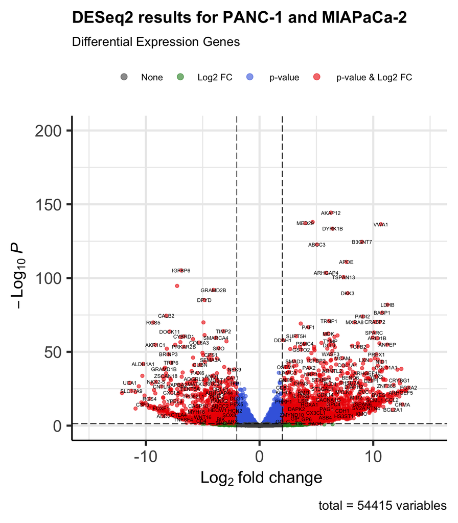

## Conclusion

Using DESeq2, we used the transcriptomes of three MIAPaCa-2 and three PANC-1 cell samples in this experiment to analyze the differences in expression. More than 7000 DEGs were found, and the gene with the largest Log2FoldChange was confirmed. After that, we performed a quality check and presented our findings using certain visualization tools. The upregulated and downregulated genes in PANC-1 should be looked at in a systematic order based on LFC or shrunken LFC and their downstream protein translations should be researched next to potentially aid in targeted therapies for pancreatic cancer.

## References

Sarantis P, Koustas E, Papadimitropoulou A, Papavassiliou AG, Karamouzis MV. Pancreatic ductal adenocarcinoma: Treatment hurdles, tumor microenvironment and immunotherapy. World J Gastrointest Oncol. 2020 Feb 15;12(2):173-181. doi: 10.4251/wjgo.v12.i2.173. PMID: 32104548; PMCID: PMC7031151.

Shen Y, Pu K, Zheng K, Ma X, Qin J, Jiang L, Li J. Differentially Expressed microRNAs in MIA PaCa-2 and PANC-1 Pancreas Ductal Adenocarcinoma Cell Lines are Involved in Cancer Stem Cell Regulation. Int J Mol Sci. 2019 Sep 10;20(18):4473. doi: 10.3390/ijms20184473. PMID: 31510100; PMCID: PMC6770012.

Vorvis C, Hatziapostolou M, Mahurkar-Joshi S, Koutsioumpa M, Williams J, Donahue TR, Poultsides GA, Eibl G, Iliopoulos D. Transcriptomic and CRISPR/Cas9 technologies reveal FOXA2 as a tumor suppressor gene in pancreatic cancer. Am J Physiol Gastrointest Liver Physiol. 2016 Jun 1;310(11):G1124-37. doi: 10.1152/ajpgi.00035.2016. Epub 2016 May 5. PMID: 27151939; PMCID: PMC5005285.

Milan M, Balestrieri C, Alfarano G, Polletti S, Prosperini E, Spaggiari P, Zerbi A, Diaferia GR, Natoli G. FOXA2 controls the cis-regulatory networks of pancreatic cancer cells in a differentiation grade-specific manner. EMBO J. 2019 Oct 15;38(20):e102161. doi: 10.15252/embj.2019102161. Epub 2019 Sep 17. PMID: 31531882; PMCID: PMC6792020.